# SDM assignment

# Solutions

Load the packages required for the analysis: `library(tidyverse); library(dismo); library(raster); library(sp); library(sf)`.

```r
library(tidyverse)
library(dismo)
library(raster)
library(sp)
library(sf)
```

Create a CRS string in geographic and UTM projection.

```r
latlongCRS <- "+proj=longlat +datum=WGS84 +no_defs +ellps=WGS84 +towgs84=0,0,0"
utmproj <- "+proj=utm +zone=34 +south +datum=WGS84 +units=m +no_defs"
```

Read in the species occurrence csv file (Pachydactylus geitje.csv) and convert it to a simple feature object. Convert the spatial object to UTM projection. You will have to specify the names of the columns containing the coordinate data. You can do this step using the pipe operator or by creating each object one at a time.

```r
spp_occ_all <- read_csv("data/spp_data/Pachydactylus geitje.csv") %>%
  st_as_sf(., coords = c("decimallon", "decimallat"), crs = latlongCRS) %>%
  st_transform(crs = utmproj)
```

**Q1:** Print out the column names of the sf object. How many fields does the occurrence data object have? Use the length() function.

```r
names(spp_occ_all)
```

```
 [1] "unique_code"     "vm_number"       "sp_code"
 [4] "collection"      "basis_of_record" "collector"
 [7] "country"         "state_prov"      "locality"
[10] "coords_unc"      "Year"            "month"
[13] "day"             "order"           "family"
[16] "genus"           "species"         "taxon_name"
[19] "common_nam"      "red_data_s"      "url"
[22] "geometry"
```

```r
length(names(spp_occ_all))
```

```
[1] 22
```

Using `dplyr::rename`, rename the following columns: `common_nam` to `common_name`; `taxon_name` to `scientific_name`; `Year` to `year` and; `red_data_s` to `red_list_status`.

```r
spp_occ_all <- spp_occ_all %>%
  rename(common_name = common_nam,
         scientific_name = taxon_name,
         red_list_status = red_data_s,
         year = Year)
```

**Q2:** Print out the column names again to confirm changes

```r
names(spp_occ_all)
```

```
 [1] "unique_code"     "vm_number"       "sp_code"
 [4] "collection"      "basis_of_record" "collector"
 [7] "country"         "state_prov"      "locality"
[10] "coords_unc"      "year"            "month"
[13] "day"             "order"           "family"
[16] "genus"           "species"         "scientific_name"
[19] "common_name"     "red_list_status" "url"
[22] "geometry"
```

There are a number of points which have duplicates geographical coordinates. Remove the duplicates using `dplyr::distinct(geometry, .keep_all = TRUE)` so that the resulting object contains unique spatial occurrence records.

```r
spp_occ_all <- spp_occ_all %>%
  distinct(geometry, .keep_all = TRUE)
```

**Q3:** How many points were removed from the dataset?

```r
728 - 387
```

```
[1] 341
```

Using `unique()` check if there are any spelling mistakes in the species name (*Pachydactylus geitje*).

```r
unique(spp_occ_all$scientific_name)
```

```
[1] "Pachydactylus geitje"  "Pachydactyylus geitje" "Pachydactylus getje"
```

**Q4:** Using `which()`, correct any spelling mistakes and re-run `unique` to confirm corrections.

```r
which(spp_occ_all$scientific_name == "Pachydactyylus geitje")
```

```
[1] 3
```

```r
which(spp_occ_all$scientific_name == "Pachydactylus getje")
```

```
[1] 59
```

```r
spp_occ_all$scientific_name[3] <- "Pachydactylus geitje"
spp_occ_all$scientific_name[59] <- "Pachydactylus geitje"

unique(spp_occ_all$scientific_name)
```

```
[1] "Pachydactylus geitje"
```

The occurrence data have been collected over a number of years and some records do not have any date information.  
**Q5:** Check the unique values of the `year` variable.

```r
unique(spp_occ_all$year)
```

```
 [1]    0 1940 2007 1983 2008 2006 2005 1986 1992 1929 1955 2011 2004 1978
[15] 2003 1984 2000 2014 1980 1976 1985   NA 1991 2015 2012 1993 2013 1994
[29] 1988 1982 2001 2002 1989 1925 1979 1977 1965 1998 1962 1996 1999
```

**Q6:** Using `table()` check the frequency of each year, how many year values are equal to `0`?

```r
table(spp_occ_all$year)
```

```
   0 1925 1929 1940 1955 1962 1965 1976 1977 1978 1979 1980 1982 1983 1984
 193    1    1    4    1    1    1    1    1    2    3    2    3   17   15
1985 1986 1988 1989 1991 1992 1993 1994 1996 1998 1999 2000 2001 2002 2003
   3    7    2    1   10    8    5    2    1    1    1    4    1    1    8
2004 2005 2006 2007 2008 2011 2012 2013 2014 2015
  15   18    8   16   17    1    2    3    3    1
```

**Q7:** Using `is.na()`, check how many year values are NA.

```r
length(which(is.na(spp_occ_all$year)))
```

```
[1] 2
```

Filter the spatial occurrence dataset to remove `0` values, remove `NA` values and keep only records collected in 1960 or later. Create a new object with the filtered data set.

```r
spp_occ <- spp_occ_all %>%
  filter(year != 0) %>%
  filter(!is.na(year)) %>%
  filter(year >= 1960)
```

**Q8:** How many rows were removed during the filtering process (use `nrow()`)?

```r
nrow(spp_occ_all) - nrow(spp_occ)
```

```
[1] 202
```

**Q9:** Print the year column as a vector to look for any obvious mistakes.

```r
spp_occ$year
```

```
 [1] 2007 2007 1983 1983 2008 2006 2005 1986 1992 1986 2008 2008 2008 2008
[15] 2008 2007 2006 2011 2008 2008 2007 2005 1986 1986 2006 1986 2008 2004
[29] 2004 1978 2004 2005 2008 2006 2003 1984 2003 2000 2008 1984 2008 2007
[43] 2005 2014 1980 1986 2004 2000 2003 2007 1986 1976 2004 2004 1985 2007
[57] 1983 1985 2004 2004 2007 1992 1984 1992 1992 2007 1983 1991 2005 1984
[71] 2007 2007 2007 1983 2005
 [ reached getOption("max.print") -- omitted 110 entries ]
```

**Q10:** Using `ggplot()` create a histograms of the year and month variables. Customise the axis labels, plot title, binwidth, color and fill for each plot. Write both plots to PDF (remember to use `dev.off()`).

```r
p1 <- spp_occ %>%
  ggplot(aes(x = year))+
  geom_histogram(binwidth = 1, fill = "white", col = "black")+
  labs(x = "Observation year",
       y = "Frequency",
       title = "Histogram of dates for Ocellated Gecko records")

p2 <- spp_occ %>%
  ggplot(aes(x = month))+
  geom_histogram(binwidth = 1, fill = "white", col = "black")+
  labs(x = "Observation month",
       y = "Frequency",
       title = "Histogram of dates for Ocellated Gecko records")

pdf("data/year_historgam.pdf")
p1
dev.off()
```

```r
pdf("data/month_historgam.pdf")
p2
dev.off()
```

Import the Western Cape provincial shapefile and project the data sot that the layers matches the coordinate reference system of the occurrence points (UTM projection).

```r
wc <- sf::st_read("data/Western_Cape.shp", crs = latlongCRS) %>%
  st_transform(crs = utmproj)
```

**Q11:** Create a plot of the occurrence points overlaid onto the provincial shapefile using `ggplot`. Add a plot title and customise the size and color of occurrence points and change the theme to black and white. Write the plot to PDF.

```r
p3 <- ggplot()+
  geom_sf(data = wc)+
  geom_sf(data = spp_occ, size = 1.2, col = "blue")+
  theme_bw()+
  labs(title = "Occurrence points of Pachydactylus geitje")

pdf("data/occ_points_map.pdf")
p3
dev.off()
```

Using `dir()`, create a list of all the environmental rasters in the environmenal_data folder. Import all the rasters into a single RasterStack. Use the projectRaster function to convert the raster stack to UTM projection

```r
env_list <- dir("data/environmental_data/", pattern = ".tif", full.names = TRUE)
env_stack <- raster::stack(env_list)
env_stack <- projectRaster(env_stack, crs = utmproj)
```

**Q12:** Plot the raster stack.

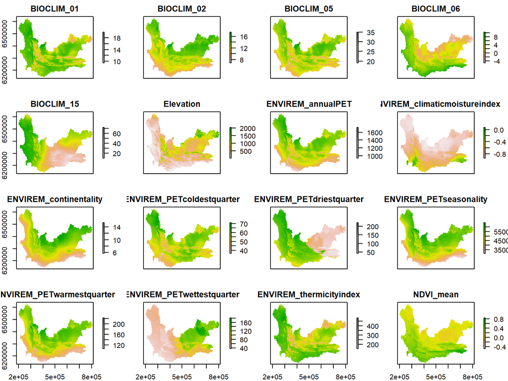

```r
plot(env_stack)
```

**Q13:** Print out the names of each raster layer using `names()`.

```r
names(env_stack)
```

```
 [1] "BIOCLIM_01"                    "BIOCLIM_02"
 [3] "BIOCLIM_05"                    "BIOCLIM_06"
 [5] "BIOCLIM_15"                    "Elevation"
 [7] "ENVIREM_annualPET"             "ENVIREM_climaticmoistureindex"
 [9] "ENVIREM_continentality"        "ENVIREM_PETcoldestquarter"
[11] "ENVIREM_PETdriestquarter"      "ENVIREM_PETseasonality"
[13] "ENVIREM_PETwarmestquarter"     "ENVIREM_PETwettestquarter"
[15] "ENVIREM_thermicityindex"       "NDVI_mean"
[17] "TRI"                           "TWI"
```

Using `usdm::vifcor`, reduce collinearity in the predictor variables (specify your own threshold).

```r
var_reduced <- usdm::vifcor(env_stack, th=0.6)
```

**Q14:** Print the results of the step above. Which variables have been retained?

```r
var_reduced
```

```
12 variables from the 18 input variables have collinearity problem:

ENVIREM_PETseasonality BIOCLIM_06 Elevation ENVIREM_annualPET BIOCLIM_01 ENVIREM_continentality BIOCLIM_02 BIOCLIM_05 ENVIREM_climaticmoistureindex ENVIREM_PETwettestquarter ENVIREM_PETwarmestquarter TRI

After excluding the collinear variables, the linear correlation coefficients ranges between:
min correlation ( TWI ~ ENVIREM_PETdriestquarter ):  0.03144013
max correlation ( ENVIREM_thermicityindex ~ ENVIREM_PETcoldestquarter ):  0.5434969

---------- VIFs of the remained variables --------
                  Variables      VIF
1                BIOCLIM_15 1.465490
2 ENVIREM_PETcoldestquarter 2.882067
3  ENVIREM_PETdriestquarter 1.531497
4   ENVIREM_thermicityindex 3.147672
5                 NDVI_mean 2.351774
6                       TWI 1.471627
```

Using `usdm::exclude`, exclude the collinear variables identified in the previous step from the `RasterStack`.

```r
env_stack<- usdm::exclude(env_stack,var_reduced)
```

**Q15:** Re-plot the raster data

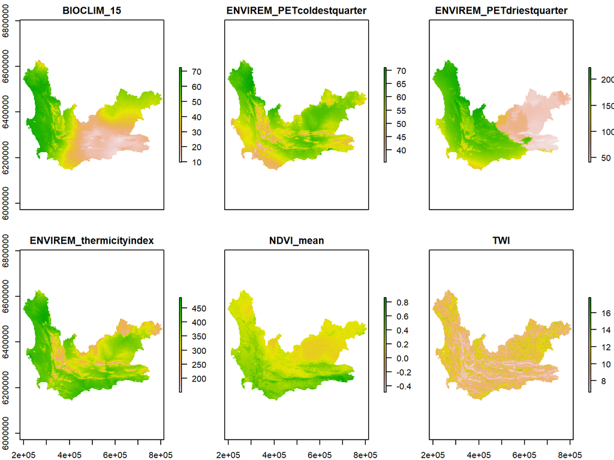

```r
plot(env_stack)
```

Create a sample of 10 000 background points from the RSA provincial shapefile.

```r
n_points <- 10000
bck_points <- st_sample(wc, n_points) %>%
  st_sf()
```

**Q16:** Plot the background points and presence points on the RSA map using `ggplot()`. Use different colors for the different classes of points. Adjust the size of the background points to improve the plot aesthetics.

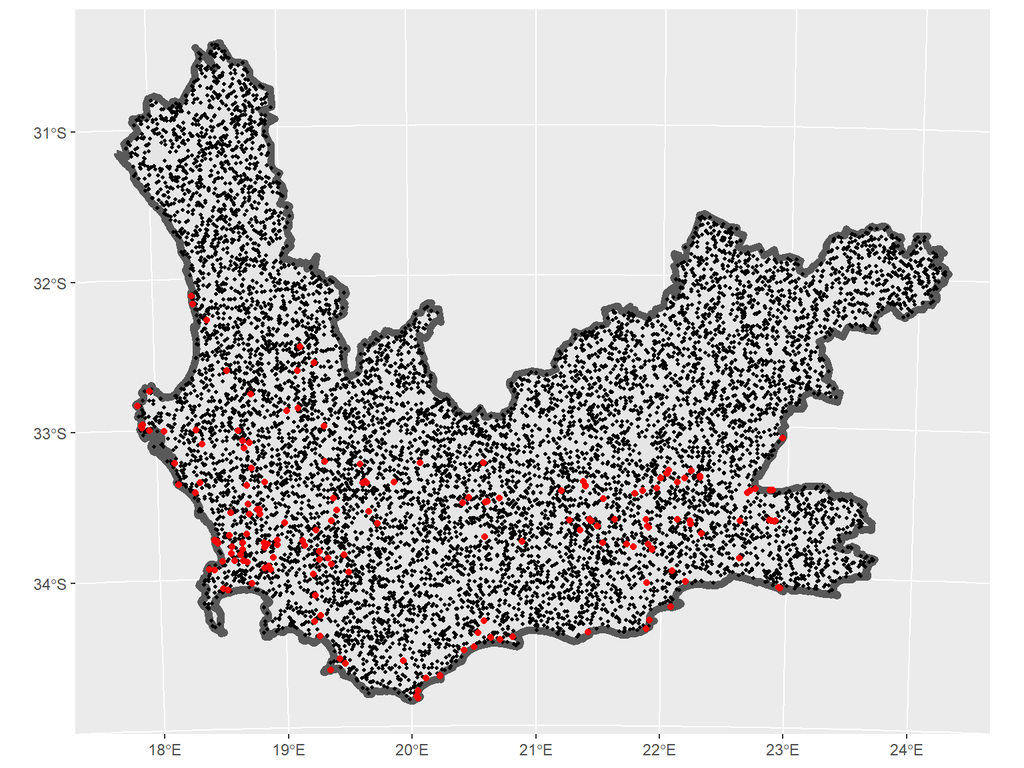

```r
ggplot()+
  geom_sf(data = wc, size = 2)+
  geom_sf(data = bck_points, size = 0.7)+
  geom_sf(data = spp_occ, col = "red")
```

Build a Maxent SDM using 10% of the occurrence points for model testing. Remember that `sf` objects need to be converted to `SpatialPointsDataFrame` objects prior to inclusion into maxent models. Customise the output path for the maxent model results.

```r
## Withold a 10% sample of occ points for testing the model
fold <- kfold(spp_occ, k=10)
occtest <- spp_occ[fold == 1, ]
occtrain <- spp_occ[fold != 1, ]

# Convert to spatialpointsdataframe
occtest <- as(occtest, "Spatial")
occtrain <- as(occtrain, "Spatial")
bck_points <- as(bck_points, "Spatial")

# Run maxent
spp_ME <- dismo::maxent(
  x = env_stack,
  p = occtrain,
  a = bck_points,
  removeDuplicates=TRUE,
  path = paste0(getwd(),"/data/SDM results"),
  args = c("randomtestpoints=30", "betamultiplier=1",
           "linear=true",
           "quadratic=true", "product=true", "threshold=true",
           "hinge=true", "threads=2", "responsecurves=true",
           "jackknife=true","askoverwrite=false"))
```

Download the maxent model results folder and open the maxent HTML file to view the results.  
**Q17:** What is the AUC of the training data?  
**Q18:** What are the top 3 predictor variables in terms of their proportional contribution?  
**Q19:** What is the shape of the response curves of these variables?

Use the testing data to evaluate the performance of the model and assign the results to an object.

```r
eval_me <- dismo::evaluate(spp_ME, x = env_stack, p = occtest, a = bck_points)
```

**Q20:** How many presence records are included in the testing data set?  
**Q21:** What is the AUC value of the test data set?  
**Q22:** What is the maxSSS threshold?

```r
eval_me
```

```
class          : ModelEvaluation
n presences    : 17
n absences     : 9970
AUC            : 0.8115848
cor            : 0.05417066
max TPR+TNR at : 0.4443412
```

**Q23:** Create a plot of the AUC curve.

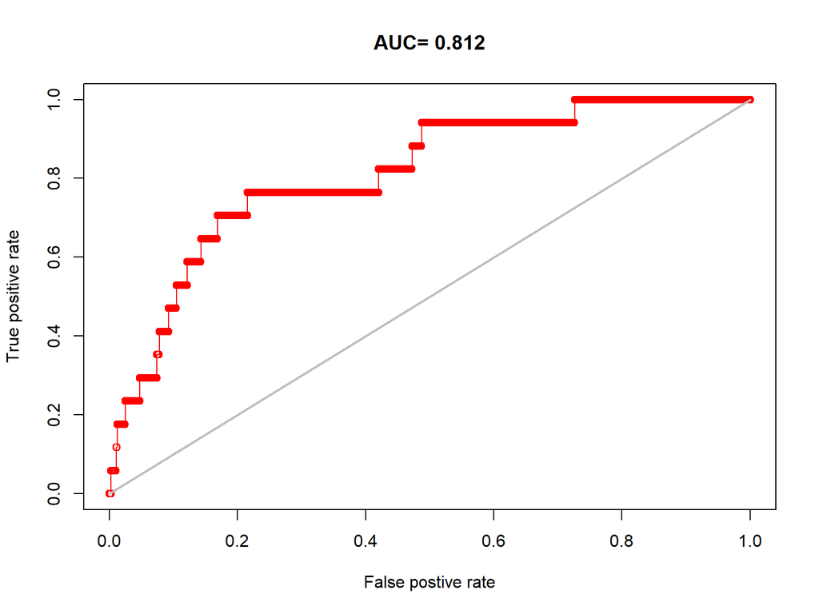

```r
plot(eval_me, "ROC")
```

Assign the maxSSS value to an object

```r
threshold(eval_me)
```

```
# A tibble: 1 x 6
  kappa spec_sens no_omission prevalence equal_sens_spec sensitivity
  <dbl>     <dbl>       <dbl>      <dbl>           <dbl>       <dbl>
1 0.995     0.444      0.0259    0.00173           0.423       0.162
```

```r
mSSS <- threshold(eval_me)[["spec_sens"]]
```

Create a predictive SDM map across the geographical extent of environmental RasterStack.

```r
spp_predict <- dismo::predict(spp_ME, env_stack, progress = "text")
```

**Q24:** Plot the SDM map and customise the title. Write the plot to PDF.

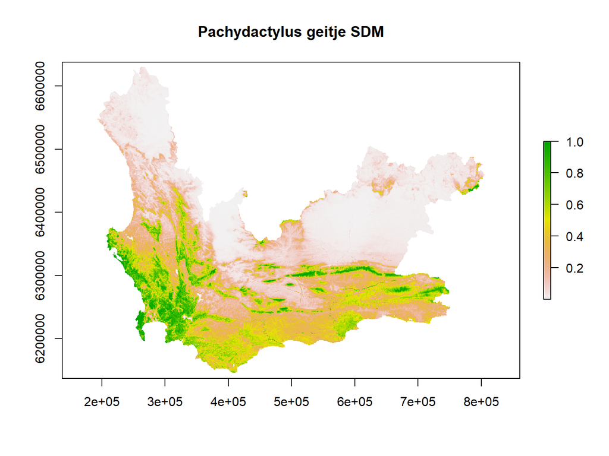

```r
p4 <- plot(spp_predict, main = "Pachydactylus geitje SDM")
```

```r
pdf("data/SDM results/spp_occSDM.pdf")
p4
```

```r
dev.off()
```

Create another plot and add the training and testing presence points to the map (each in a different color).  
**Q25:** Save the map to PDF.

```r
pdf("data/SDM results/spp_occSDM_2.pdf")
plot(spp_predict, main = "Pachydactylus geitje SDM")
plot(occtrain, pch = 16, cex = 0.5, add = TRUE)
plot(occtest, pch = 16, cex = 1, add = TRUE, col = "red")
dev.off()
```

Create a binary predictive map using the mSSS value.

```r
mSSS_matrix <- matrix(c(0,mSSS,0,
                            mSSS,1,1), ncol=3, byrow=TRUE)
binary_prediction <- reclassify(spp_predict, mSSS_matrix)
```

**Q26:** Plot the binary map, customise the title and write it to PDF.

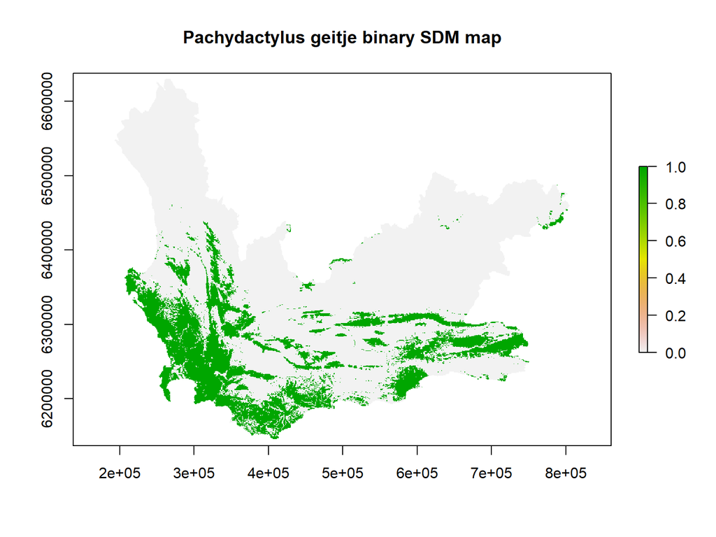

```r
plot(binary_prediction, main= "Pachydactylus geitje binary SDM map")
```

**Q27:** Write the predictive raster in a TIFF format and workspace to the results directory.

```r
raster::writeRaster(spp_predict,
                    filename = ("data/SDM results/spp_occSDM.tif"),
                    format="GTiff",
                    overwrite=TRUE)
save.image("data/SDM results/SDM_workspace.RData")
```